# H2O Workshop

Airlines Dataframe

## Requirements

For compatibility with H2O:

1. Operating Systems:
- Windows 7 or later
- OS X 10.9 or later
- Ubuntu 12.04
- RHEL/CentOS 6 or later
2. Languages:
- Scala (2.10 or later), R (3 or later), and Python (2.7.x, 3.5.x, 3.6.x) are not required to use H2O unless you want to use H2O in those environments.
- Java is always required. Supported versions include:
  - Java 7 or later. Note: Java 9 is released, but is not currently supported.
- To build H2O or run H2O tests, the 64-bit JDK is required.
- To run the H2O binary using either the command line, R, or Python packages, only 64-bit JRE is required.
3. Browser: An internet browser is required to use H2O’s web UI, Flow.
- Latest version of Chrome, Firefox, Safari, or Internet Explorer.

### About H2O

H2O is fast, scalable, open-source machine learning and deep learning. Advanced algorithms such as deep learning, boosting, and bagging ensembles are built-in.

[Download H2O](https://www.h2o.ai/h2o/) to do some machine learning.

[Documentation](http://docs.h2o.ai/h2o/latest-stable/h2o-docs/index.html).

## Set your environment

```r
# Install snippet
# source('install.R')

library(h2o)
h2o.init()
# h2o.clusterInfo()
```

## Data wrangling

[Data information](http://stat-computing.org/dataexpo/2009/the-data.html)

Prepare your data for modelling.

```r
summary(flights.hex, exact_quantiles=TRUE)
```

```
 Year           Month            DayofMonth     DayOfWeek       DepTime        CRSDepTime
 Min.   :1987   Min.   : 1.000   Min.   : 1.0   Min.   :1.000   Min.   :   1   Min.   :   0
 1st Qu.:1992   1st Qu.: 1.000   1st Qu.: 6.0   1st Qu.:2.000   1st Qu.: 929   1st Qu.: 910
 Median :1998   Median : 1.000   Median :14.0   Median :4.000   Median :1330   Median :1320
 Mean   :1998   Mean   : 1.409   Mean   :14.6   Mean   :3.821   Mean   :1346   Mean   :1313
 3rd Qu.:2003   3rd Qu.: 1.000   3rd Qu.:23.0   3rd Qu.:5.000   3rd Qu.:1735   3rd Qu.:1720
 Max.   :2008   Max.   :10.000   Max.   :31.0   Max.   :7.000   Max.   :2400   Max.   :2359
                                                                NA's   :1086
 ArrTime        CRSArrTime     UniqueCarrier FlightNum        TailNum
 Min.   :   1   Min.   :   0   US:18729      Min.   :   1.0   UNKNOW          :  179
 1st Qu.:1118   1st Qu.:1109   UA: 9434      1st Qu.: 204.0   000000          :  124
 Median :1527   Median :1516   WN: 6170      Median : 557.0   <0xE4>NKNO<0xE6>:  114
 Mean   :1505   Mean   :1485   HP: 3451      Mean   : 818.8   0               :   66
 3rd Qu.:1917   3rd Qu.:1903   PS: 3212      3rd Qu.:1242.0   N912UA          :   59
 Max.   :2400   Max.   :2359   DL:  935      Max.   :3949.0   N316AW          :   56
 NA's   :1195                                                 NA              :16024
 ActualElapsedTime CRSElapsedTime AirTime         ArrDelay          DepDelay         Origin
 Min.   : 16.0     Min.   : 17    Min.   : 14.0   Min.   :-63.000   Min.   :-16.00   DEN:3558
 1st Qu.: 71.0     1st Qu.: 71    1st Qu.: 61.0   1st Qu.: -6.000   1st Qu.: -2.00   PIT:3241
 Median :101.0     Median :102    Median : 91.0   Median :  2.000   Median :  1.00   ORD:2246
 Mean   :124.8     Mean   :125    Mean   :114.3   Mean   :  9.317   Mean   : 10.01   BUR:2021
 3rd Qu.:151.0     3rd Qu.:151    3rd Qu.:140.0   3rd Qu.: 14.000   3rd Qu.: 10.00   CLT:1781
 Max.   :475.0     Max.   :437    Max.   :402.0   Max.   :475.000   Max.   :473.00   PHL:1632
 NA's   :1195      NA's   :13     NA's   :16649   NA's   :1195      NA's   :1086
 Dest      Distance         TaxiIn            TaxiOut          Cancelled
 PHX:9317  Min.   :  11.0   Min.   :  0.000   Min.   :  0.00   Min.   :0.00000
 PHL:4482  1st Qu.: 326.0   1st Qu.:  3.000   1st Qu.:  9.00   1st Qu.:0.00000
 PIT:3020  Median : 541.0   Median :  5.000   Median : 12.00   Median :0.00000
 ORD:2103  Mean   : 730.2   Mean   :  5.381   Mean   : 14.17   Mean   :0.02469
 CLT:1542  3rd Qu.: 920.0   3rd Qu.:  6.000   3rd Qu.: 16.00   3rd Qu.:0.00000
 DEN:1470  Max.   :3365.0   Max.   :128.000   Max.   :254.00   Max.   :1.00000
           NA's   :35       NA's   :16026     NA's   :16024
 CancellationCode Diverted           CarrierDelay      WeatherDelay       NASDelay
 B :   93         Min.   :0.000000   Min.   :  0.000   Min.   :  0.0000   Min.   :  0.000
 A :   81         1st Qu.:0.000000   1st Qu.:  0.000   1st Qu.:  0.0000   1st Qu.:  0.000
 C :   47         Median :0.000000   Median :  0.000   Median :  0.0000   Median :  0.000
 NA:43757         Mean   :0.002479   Mean   :  4.048   Mean   :  0.2894   Mean   :  4.855
                  3rd Qu.:0.000000   3rd Qu.:  0.000   3rd Qu.:  0.0000   3rd Qu.:  0.000
                  Max.   :1.000000   Max.   :369.000   Max.   :201.0000   Max.   :323.000
                                     NA's   :35045     NA's   :35045      NA's   :35045
 SecurityDelay      LateAircraftDelay IsArrDelayed IsDepDelayed
 Min.   : 0.00000   Min.   :  0.00    YES:24441    YES:23091
 1st Qu.: 0.00000   1st Qu.:  0.00    NO :19537    NO :20887
 Median : 0.00000   Median :  0.00
 Mean   : 0.01702   Mean   :  7.62
 3rd Qu.: 0.00000   3rd Qu.:  0.00
 Max.   :14.00000   Max.   :373.00
 NA's   :35045      NA's   :35045
```

Quantiles and histograms

- Quantile: A sorted sample is divided into equal-sized, adjacent, subgroups. The quartiles are the 25, 50, and 75 quantiles. The percentiles are quantiles that divide a distribution into 100 equal parts. The median is the 50 quantile.

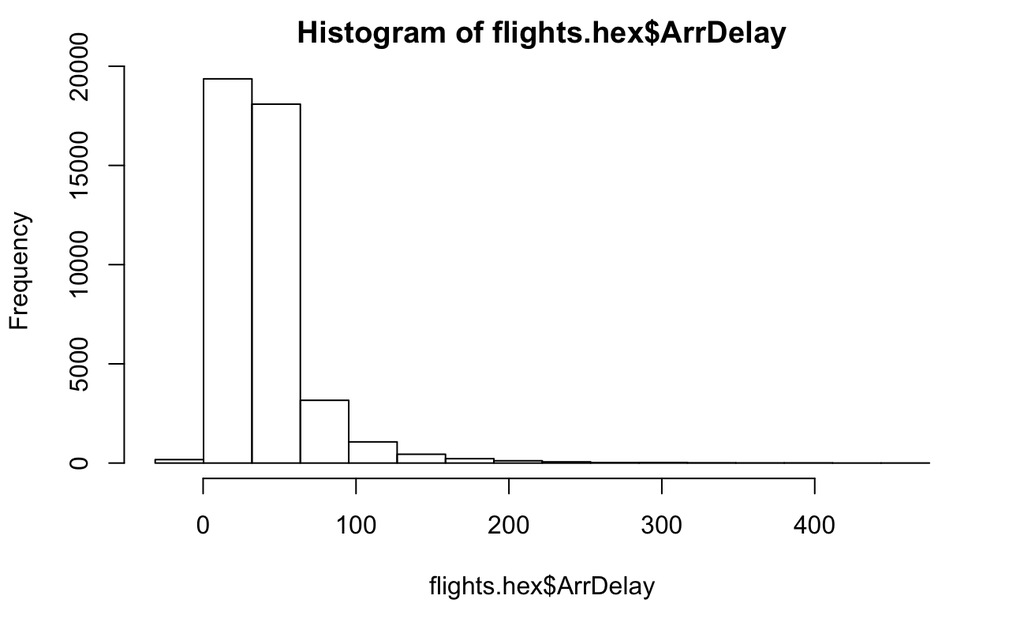